# **[Universidade Federal Rural de Pernambuco](http://ufrpe.br/)** **[Departamento de Matemática](http://www.dm.ufrpe.br/)** **[Disciplina: Análise Combinatória](https://sites.google.com/site/ricardonunesmachadojr/disciplinas/analise-combinatoria)** **[Prof. Ricardo Machado](https://sites.google.com/site/ricardonunesmachadojr/)**

## [Índice de Aulas](https://sagectu.com.br/calculo1.github.io/combinatoria.html) Aula 4

## 1 - Combinações Completas 2 - Exercícios

# Referências:

### Observação: Nota de aula produzida usando o software [SageMath](http://www.sagemath.org/), usando o notebook [Jupyter](https://jupyter.org/). Use o SageMathCell com vários exemplos em: sagectu.com.br/sagecell.html Referência bibliográfica sobre o SageMath: [1] Silva, L., Santos M., Machado, R., [*Elementos de Computação Matemática com SageMath*](https://sagectu.com.br/), SBM, 2019.

[figure not shown]

```python
load ('/home/ricardo/sage-9.0-Debian_GNU_Linux_9-x86_64/SageMath/Sage_Sync/Combinatoria/codigos.sage')
```

## 1 - Combinação Completa

### Definição 1 Diferente da Combinação Simples, na Combinação Completa é permitido a presença de elementos repetidos. O número de combinações completas é denotado por: $$ CR_n^{p } $$ Assim, as combinações completas de classe 3 dos objetos $1, 2, 3, 4$ tomados 3 a 3 são: $$ [1, 1, 1], [1, 1, 2], [1, 1, 3], [1, 1, 4], [1, 2, 2], $$$$ [1, 2, 3], [1, 2, 4], [1, 3, 3], [1, 3, 4], [1, 4, 4], $$$$ [2, 2, 2], [2, 2, 3], [2, 2, 4], [2, 3, 3], [2, 3, 4], $$$$ [2, 4, 4], [3, 3, 3], [3, 3, 4], [3, 4, 4], [4, 4, 4] $$ e $CR_4^3 = 20.$

### Exemplo 1 (SageMath) A lista com todas as combinações completas foi gerada no SageMath com o comando:

```python
Combinations([1, 1, 1, 2, 2, 2, 3, 3, 3, 4, 4, 4], 3).list()
```

```
[[1, 1, 1],
 [1, 1, 2],
 [1, 1, 3],
 [1, 1, 4],
 [1, 2, 2],
 [1, 2, 3],
 [1, 2, 4],
 [1, 3, 3],
 [1, 3, 4],
 [1, 4, 4],
 [2, 2, 2],
 [2, 2, 3],
 [2, 2, 4],
 [2, 3, 3],
 [2, 3, 4],
 [2, 4, 4],
 [3, 3, 3],
 [3, 3, 4],
 [3, 4, 4],
 [4, 4, 4]]
```

### Antes de chegar em uma fórmula para a combinação completa, vamos resolver um caso particular para ajudar no raciocínio da fórmula geral.

### Exemplo 2 De quantos modos é possível comprar 3 sorvetes em uma loja que oferece 6 sabores?

### Solução Resolver este problema é o mesmo que encontrar o número de soluções da equação: $$ x_1 + x_2 + x_3 + x_4 + x_5 + x_6 = 3, ~~~ \text{ com } x_i \geq 0 ~~~~(*)$$ na qual, cada $x_i$ representa a quantidade de sorvetes do sabor $i$. Claramente, temos a restrição $x_i\geq 0$, pois não podemos pegar uma quantidade negativas de qualquer sabor. A equação $(*)$ pode ser interpretada de tal forma que, encontrar o número de soluções será o mesmo que calcular o número de permutações com repetições. Vamos explicar esta interpretação:

### Interpretação da equação $(*)$: Coloque um traço separando uma incógnita da outra. Para representar a quantidade de sorvetes de um tipo $i$, coloque esta quantidade de bolas entre os traços que representam o sabor $i$: \begin{equation} \begin{split} x_1 ~~ & & ~~ x_2 ~~ & & ~~ x_3 ~~ & & ~~ x_4 ~~ & & ~~ x_ 5 ~~ & & ~~ x_ 6\\ 1 ~~ & & ~~ 0 ~~ & & ~~ 0 ~~ & & ~~ 0 ~~ & & ~~ 2 ~~ & & ~~ 0\\ \bullet ~~ &|& ~~ ~~ &|& ~~ ~~ &|& ~~ ~~ &|& ~~ \bullet \bullet ~~ &|& ~~ \\ \end{split} \end{equation} Essa representação de traços e bolas, significa que foi escolhido um sorvete do sabor 1 e 2 sorvetes do sabor 5, completando assim a escolha dos 3 sorvetes. \begin{equation} \begin{split} x_1 ~~ & & ~~ x_2 ~~ & & ~~ x_3 ~~ & & ~~ x_4 ~~ & & ~~ x_ 5 ~~ & & ~~ x_ 6\\ 1 ~~ & & ~~ 0 ~~ & & ~~ 1 ~~ & & ~~ 1 ~~ & & ~~ 0 ~~ & & ~~ 0\\ \bullet ~~ &|& ~~ ~~ &|& ~~ \bullet ~~ &|& ~~ \bullet ~~ &|& ~~ ~~ &|& ~~ \\ \end{split} \end{equation} Essa representação de traços e bolas, significa que foi escolhido um sorvete do sabor 1, 1 sorvete do sabor 3 e 1 sorvete do sabor 4, completando assim a escolha dos 3 sorvetes. Agora, vamos encontrar o número de soluções da Equação $(*)$.

```python
P(8, 5, 3)
```

[output not shown]

### Teorema 1 $$ CR_n^p = PR_{p+n-1}^{p, n-1} = C_{p+n-1}^p$$

### Demonstração Calcular $CR_n^p$ é o mesmo que encontrar o número de soluções da equação: $$ x_1 + x_2 + x_3 + \ldots + x_n = p, ~~~ \text{ com } x_i \geq 0 $$ Usando a ideia da representação de "bolas e traços" vamos ficar com $p$ bolas e $n-1$ traços. O cálculo do número de permutações destes $p+n-1$ objetos com $p$ objetos de um tipo e $n-1$ objetos de outro tipo é dado por: $$ PR_{p+n-1}^{p, n-1} = C_{p+n-1}^p$$ $\blacksquare$

### Definindo a função para calcular o número de combinações com repetições no SageMath Vamos definir a função `CR(n, p) = PR(p+n-1, p, n-1)`

```python
CR(n, p) = PR(p+n-1, p, n-1)
```

```python
CR(3, 5)
```

```
21
```

### Exemplo 3 Quantas são as soluções inteiras e não negativas de $$ x_1 + x_2 + x_3 + \ldots + x_{10} = 20?$$

### Solução $$ CR_{10}^{20} = 10015005$$

```python
CR(10, 20)
```

```
10015005
```

### Exemplo 4 Quantas são as soluções inteiras da equação $$ x_1 + x_2 + x_3 = 15$$ com $x_1>0$, $x_2\geq 2$ e $x_3 \geq 4$?

### Solução Defina $$ x_1 = x+1, $$$$ x_2 = y+2 $$ e $$ x_3 = z+4 $$ Substituindo, temos $$ (x+1) + (y+2) + (z+4) = 15 $$ ou seja $$ x + y + z = 8 ~~~~ (\blacklozenge) $$ Desta forma, o número de soluções de ($\blacklozenge$) será a solução do problema, pois, quando $x=0$ teremos $x_1=1$, quando $y=0$ teremos $x_2=2$ e quando $z=0$ teremos $x_3=4$. Portanto a resposta é $$ CR_3^{8} = 45. $$

```python
CR(3, 8)
```

```
45
```

### Exemplo (VESTIBULAR UFPE – UFRPE / 1998 2ª ETAPA) Semelhante ao dominó, mas feito de pedras triangulares equiláteras, o jogo de trominó apresenta na face triangular superior um certo número de pontos com repetições, escolhidos de 1 a n, dispostos ao longo de cada aresta (ver figura).

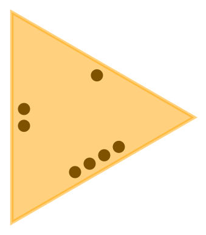

```python
tromino()
```

### Quantas peças há no trominó, supondo n = 6?

### Solução. Temos que escolher os valores de cada um dos 3 lados de cada peça do trominó. Como os valores vão de 1 até 6 e são 3 lados, o número de peças do trominó para $n=6$ é o número de soluções inteiras não negativas da equação: $$ x_1 + x_2 + x_3 + x_4 + x_ 5 + x_ 6 = 3. $$ Portanto a quantidade de peças é: $$ CR_6^{3} = 56. $$

```python
CR(6, 3)
```

```
56
```

### 2 - Exercícios Quantas são as soluções inteiras positivas de $x+y+z+w = 15$? $$ $$ Quantas são as soluções inteiras positivas de $x+y+z+w < 15$? $$ $$ Os números inteiros compreendidos entre $100.000.000$ e $999.999.999$ são divididos em classes de modo que dois números diferentes estão na mesma classe se e só se eles têm os mesmos algarismos, diferindo apenas na ordem. Quantas classes são assim formadas? $$ $$ Quantas são as soluções inteiras não-negativas de $x+y+z+w = 30$ nas quais $x>w$? $$ $$ Quantos inteiros entre $1$ e $100.000.000$, inclusive, possui a propriedade: "cada dígito é menor ou igual ao seu sucessor"? $$ $$ De quantas maneiras é possível colocar 10 anéis diferentes em $8$ dedos?